# Full Model

Julia Schwarz

28/10/2021

## Packages

## Data File

Pre-processed data file (critical items only), outliers and practice trials removed. 3560 observations.

## Variable Prep

## Subsets

## Full Data Model

### Maximal Model

We first fitted a model to the complete data set.

NOTE: For the full model it might be better to replace group with actual ages (continuous predictor) since there seems to be a lot of variation in the GROUP predictor.

### Testing Random Structure

First, the random effects SUBJECT and ITEM were tested. To avoid overfitting our sub-sample data set, only random intercepts were included. Both SUBJECT and ITEM contributed significantly to the model fit and were retained in all subsequent models.

### Testing Fixed Structure

6 interactions and 4 main effects (sum contrast coded) were included in the maximal model structure (see below). The model was then optimized with the step function (checked against manual reduction).

```r
lmm.all <- lmerTest::lmer(RT ~
                            AUDIO:VISUAL +
                            AUDIO:GROUP +
                            VISUAL:GROUP +
                            AUDIO:PREDICT +
                            VISUAL:PREDICT +
                            GROUP:PREDICT +

                            GROUP +
                            PREDICT +
                            VISUAL +
                            AUDIO +

                            (1 | SUBJECT) +
                            (1 | ITEM),

                           data,
                           lmerControl(optimizer = "bobyqa") ,
                           REML=F, na.action=na.omit)
summary(lmm.all)
```

```
## Linear mixed model fit by maximum likelihood . t-tests use Satterthwaite's
##   method [lmerModLmerTest]
## Formula: RT ~ AUDIO:VISUAL + AUDIO:GROUP + VISUAL:GROUP + AUDIO:PREDICT +
##     VISUAL:PREDICT + GROUP:PREDICT + GROUP + PREDICT + VISUAL +
##     AUDIO + (1 | SUBJECT) + (1 | ITEM)
##    Data: data
## Control: lmerControl(optimizer = "bobyqa")
##
##      AIC      BIC   logLik deviance df.resid
##  49113.0  49199.5 -24542.5  49085.0     3546
##
## Scaled residuals:
##     Min      1Q  Median      3Q     Max
## -3.1731 -0.5304 -0.1106  0.3856  5.4940
##
## Random effects:
##  Groups   Name        Variance Std.Dev.
##  ITEM     (Intercept)   7343    85.69
##  SUBJECT  (Intercept) 140771   375.20
##  Residual              50080   223.79
## Number of obs: 3560, groups:  ITEM, 240; SUBJECT, 32
##
## Fixed effects:
##                  Estimate Std. Error       df t value Pr(>|t|)
## (Intercept)      1047.771     66.663   32.447  15.717  < 2e-16 ***
## GROUP1            171.053    132.870   32.005   1.287 0.207198
## PREDICT1           88.563     13.400  233.894   6.609 2.58e-10 ***
## VISUAL1           -31.451      7.767 3474.195  -4.050 5.24e-05 ***
## AUDIO1            -25.825      7.655 3401.580  -3.373 0.000751 ***
## AUDIO1:VISUAL1     33.969     15.496 3476.161   2.192 0.028445 *
## AUDIO1:GROUP1       4.819     15.632 3500.466   0.308 0.757915
## VISUAL1:GROUP1     -0.346     15.337 3410.700  -0.023 0.982004
## AUDIO1:PREDICT1   -32.434     15.320 3407.646  -2.117 0.034324 *
## VISUAL1:PREDICT1   -6.914     15.480 3448.388  -0.447 0.655145
## GROUP1:PREDICT1   -34.963     15.212 3362.666  -2.298 0.021599 *
## ---
## Signif. codes:  0 '***' 0.001 '**' 0.01 '*' 0.05 '.' 0.1 ' ' 1
##
## Correlation of Fixed Effects:
##             (Intr) GROUP1 PREDIC VISUAL1 AUDIO1 AUDIO1:V AUDIO1:G VISUAL1:G
## GROUP1       0.000
## PREDICT1     0.001  0.000
## VISUAL1     -0.001  0.000 -0.009
## AUDIO1      -0.001  0.000 -0.008  0.009
## AUDIO1:VISU  0.000 -0.001  0.003 -0.021  -0.011
## AUDIO1:GROU -0.001 -0.002  0.002 -0.025  -0.006  0.004
## VISUAL1:GRO  0.000  0.000 -0.001  0.022   0.018  0.012   -0.018
## AUDIO1:PRED -0.001 -0.001 -0.012  0.010   0.030 -0.012    0.003   -0.002
## VISUAL1:PRE -0.001  0.000 -0.007  0.022   0.010 -0.010   -0.006   -0.008
## GROUP1:PRED  0.000  0.001  0.015  0.001  -0.012 -0.006   -0.008   -0.019
##             AUDIO1:P VISUAL1:P
## GROUP1
## PREDICT1
## VISUAL1
## AUDIO1
## AUDIO1:VISU
## AUDIO1:GROU
## VISUAL1:GRO
## AUDIO1:PRED
## VISUAL1:PRE  0.007
## GROUP1:PRED  0.000   -0.004
```

### Optimized Model Summary (all data):

The optimized full data model included three significant interactions between (1) acoustic mask effect and visual mask effect, (2) acoustic mask effect and predictability effect, and (3) group (adults vs. children) and predictability effect. Predictability, visual mask effect, and acoustic mask effect were main effects.

|  | RT |  |  |
| --- | --- | --- | --- |
| Predictors | Estimates | CI | p |
| (Intercept) | 1047.76 | 912.86 – 1182.66 | **<0.001** |
| GROUP1 | 171.15 | -97.79 – 440.08 | 0.212 |
| PREDICT1 | 88.51 | 62.21 – 114.82 | **<0.001** |
| VISUAL1 | -31.32 | -46.55 – -16.10 | **<0.001** |
| AUDIO1 | -25.78 | -40.79 – -10.77 | **0.001** |
| AUDIO1 * VISUAL1 | 33.89 | 3.49 – 64.28 | **0.029** |
| AUDIO1 * PREDICT1 | -32.40 | -62.46 – -2.35 | **0.035** |
| PREDICT1 * GROUP1 | -34.96 | -64.80 – -5.13 | **0.022** |
| Random Effects |  |  |  |
| σ<sup>2</sup> | 50163.71 |  |  |
| τ<sub>00</sub> <sub>ITEM</sub> | 7373.63 |  |  |
| τ<sub>00</sub> <sub>SUBJECT</sub> | 150152.39 |  |  |
| ICC | 0.76 |  |  |
| N <sub>SUBJECT</sub> | 32 |  |  |
| N <sub>ITEM</sub> | 240 |  |  |
| Observations | 3560 |  |  |
| Marginal R<sup>2</sup> / Conditional R<sup>2</sup> | 0.045 / 0.769 |  |  |

### Optimized Model plotted (all data)

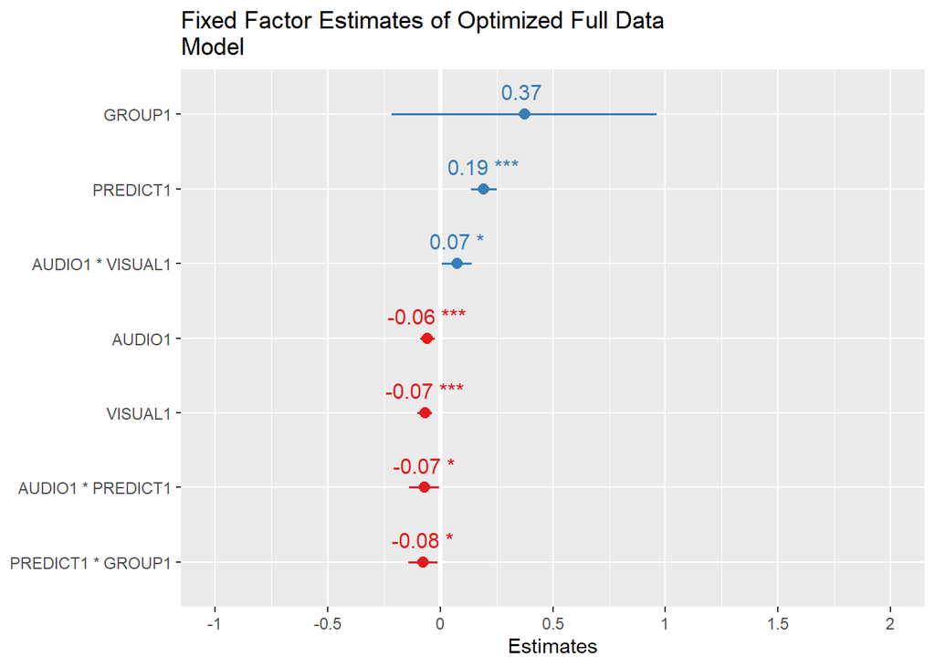

## Adults

### Adults Start Model

Adult and Child data models followed the same analysis pipeline, starting with the same maximal model (minus factor group).

```r
lmm.adults <- lmerTest::lmer(RT ~
                            AUDIO:VISUAL +
                            AUDIO:PREDICT +
                            VISUAL:PREDICT +

                            PREDICT +
                            VISUAL +
                            AUDIO +

                            (1 | SUBJECT) +
                            (1 | ITEM),

                           adults,
                           lmerControl(optimizer = "bobyqa") ,
                           REML=F, na.action=na.omit)
summary(lmm.adults)
```

```
## Linear mixed model fit by maximum likelihood . t-tests use Satterthwaite's
##   method [lmerModLmerTest]
## Formula: RT ~ AUDIO:VISUAL + AUDIO:PREDICT + VISUAL:PREDICT + PREDICT +
##     VISUAL + AUDIO + (1 | SUBJECT) + (1 | ITEM)
##    Data: adults
## Control: lmerControl(optimizer = "bobyqa")
##
##      AIC      BIC   logLik deviance df.resid
##  24465.0  24520.0 -12222.5  24445.0     1798
##
## Scaled residuals:
##     Min      1Q  Median      3Q     Max
## -3.7599 -0.4887 -0.0885  0.3789  6.3015
##
## Random effects:
##  Groups   Name        Variance Std.Dev.
##  ITEM     (Intercept)   5343    73.1
##  SUBJECT  (Intercept) 103505   321.7
##  Residual              37666   194.1
## Number of obs: 1808, groups:  ITEM, 240; SUBJECT, 16
##
## Fixed effects:
##                  Estimate Std. Error       df t value Pr(>|t|)
## (Intercept)       961.891     80.700   16.108  11.919  2.1e-09 ***
## PREDICT1          104.889     13.179  230.805   7.959  7.8e-14 ***
## VISUAL1           -25.949      9.481 1742.794  -2.737  0.00627 **
## AUDIO1            -29.038      9.702 1792.127  -2.993  0.00280 **
## AUDIO1:VISUAL1     33.772     19.177 1779.025   1.761  0.07840 .
## AUDIO1:PREDICT1   -42.649     19.337 1787.695  -2.206  0.02754 *
## VISUAL1:PREDICT1  -14.015     18.943 1734.543  -0.740  0.45950
## ---
## Signif. codes:  0 '***' 0.001 '**' 0.01 '*' 0.05 '.' 0.1 ' ' 1
##
## Correlation of Fixed Effects:
##             (Intr) PREDIC VISUAL1 AUDIO1 AUDIO1:V AUDIO1:P
## PREDICT1     0.001
## VISUAL1      0.000 -0.013
## AUDIO1      -0.002 -0.004 -0.002
## AUDIO1:VISU  0.001  0.005 -0.016  -0.022
## AUDIO1:PRED  0.000 -0.018  0.015   0.012 -0.009
## VISUAL1:PRE -0.001 -0.005  0.055   0.016 -0.020   -0.002
```

### Optimizing

### Summary Optimized Adult Model

The optimized adult model included a significant interaction between acoustic mask effect and target predictability effect, and a marginal interaction between acoustic and visual mask effect (NOTE: probably due to power), as well as the main effects predictability, visual mask effect, and acoustic mask effect.

|  | RT |  |  |
| --- | --- | --- | --- |
| Predictors | Estimates | CI | p |
| (Intercept) | 961.83 | 803.66 – 1120.00 | **<0.001** |
| PREDICT1 | 104.84 | 79.04 – 130.65 | **<0.001** |
| VISUAL1 | -25.56 | -44.11 – -7.00 | **0.007** |
| AUDIO1 | -28.91 | -47.93 – -9.89 | **0.003** |
| AUDIO1 * VISUAL1 | 33.47 | -4.12 – 71.06 | 0.081 |
| AUDIO1 * PREDICT1 | -42.67 | -80.58 – -4.77 | **0.027** |
| Random Effects |  |  |  |
| σ<sup>2</sup> | 37691.09 |  |  |
| τ<sub>00</sub> <sub>ITEM</sub> | 5318.48 |  |  |
| τ<sub>00</sub> <sub>SUBJECT</sub> | 103506.46 |  |  |
| ICC | 0.74 |  |  |
| N <sub>SUBJECT</sub> | 16 |  |  |
| N <sub>ITEM</sub> | 240 |  |  |
| Observations | 1808 |  |  |
| Marginal R<sup>2</sup> / Conditional R<sup>2</sup> | 0.021 / 0.748 |  |  |

### Adult Model Fixed Effects Plotted

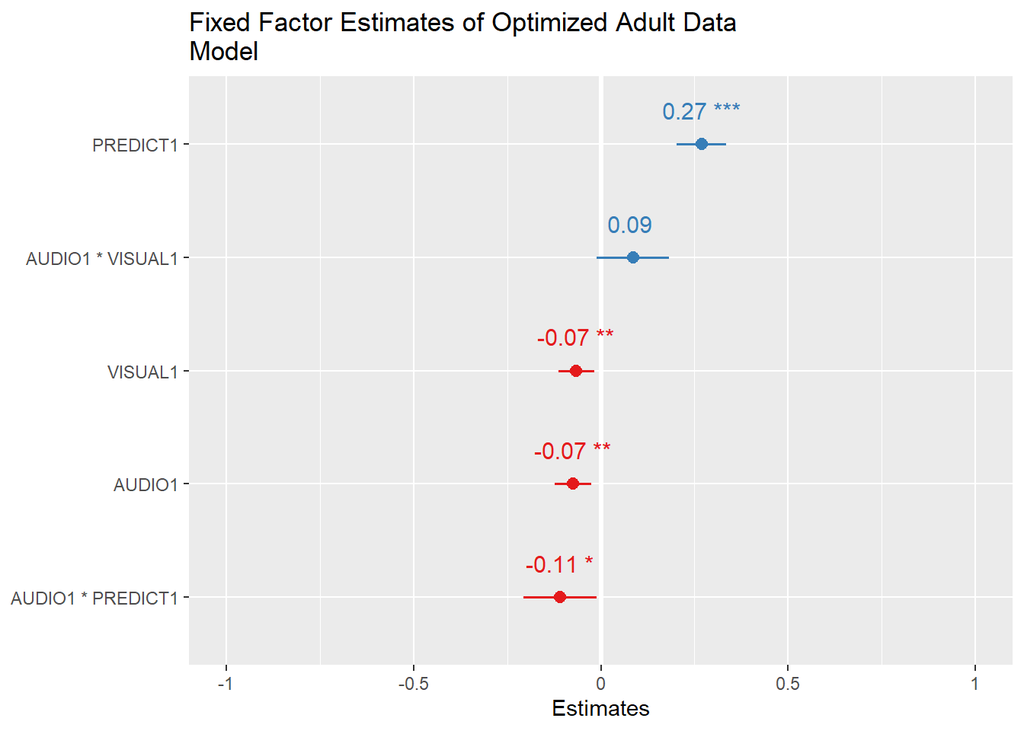

## Children

### Children Start Model

```r
lmm.children <- lmerTest::lmer(RT ~
                            AUDIO:VISUAL +
                            AUDIO:PREDICT +
                            VISUAL:PREDICT +

                            PREDICT +
                            VISUAL +
                            AUDIO +

                            (1 | SUBJECT) +
                            (1 | ITEM),

                           children,
                           lmerControl(optimizer = "bobyqa") ,
                           REML=F, na.action=na.omit)
summary(lmm.children)
```

```
## Linear mixed model fit by maximum likelihood . t-tests use Satterthwaite's
##   method [lmerModLmerTest]
## Formula: RT ~ AUDIO:VISUAL + AUDIO:PREDICT + VISUAL:PREDICT + PREDICT +
##     VISUAL + AUDIO + (1 | SUBJECT) + (1 | ITEM)
##    Data: children
## Control: lmerControl(optimizer = "bobyqa")
##
##      AIC      BIC   logLik deviance df.resid
##  24605.0  24659.6 -12292.5  24585.0     1742
##
## Scaled residuals:
##     Min      1Q  Median      3Q     Max
## -2.8283 -0.5738 -0.1227  0.4056  4.8580
##
## Random effects:
##  Groups   Name        Variance Std.Dev.
##  ITEM     (Intercept)  10511   102.5
##  SUBJECT  (Intercept) 177481   421.3
##  Residual              61973   248.9
## Number of obs: 1752, groups:  ITEM, 240; SUBJECT, 16
##
## Fixed effects:
##                   Estimate Std. Error        df t value Pr(>|t|)
## (Intercept)      1133.9794   105.7065   16.1301  10.728 9.43e-09 ***
## PREDICT1           69.8893    18.0113  215.8298   3.880 0.000139 ***
## VISUAL1           -31.2540    12.4930 1701.4612  -2.502 0.012453 *
## AUDIO1            -23.4472    12.2937 1654.1249  -1.907 0.056661 .
## AUDIO1:VISUAL1     34.9168    24.9861 1703.9672   1.397 0.162461
## AUDIO1:PREDICT1    -1.1696    24.5969 1659.8381  -0.048 0.962081
## VISUAL1:PREDICT1    0.5334    24.9348 1690.9466   0.021 0.982937
## ---
## Signif. codes:  0 '***' 0.001 '**' 0.01 '*' 0.05 '.' 0.1 ' ' 1
##
## Correlation of Fixed Effects:
##             (Intr) PREDIC VISUAL1 AUDIO1 AUDIO1:V AUDIO1:P
## PREDICT1     0.001
## VISUAL1     -0.001 -0.015
## AUDIO1      -0.002 -0.012 -0.016
## AUDIO1:VISU  0.001 -0.003 -0.006  -0.007
## AUDIO1:PRED -0.001 -0.024  0.012   0.030 -0.008
## VISUAL1:PRE -0.001 -0.009  0.027   0.011 -0.010   -0.017
```

### Optimizing

The child model optimized through the step function only included the main effects predictability and visual mask effect. For comparison reasons, however, the summarized model below includes the same predictors as the adult model.

### Summary Optimized Child Model

For comparison, the child model is mirrored with the adult model. The main effect predictability and visual mask effect were significant, the acoustic mask effect marginal (p=0.056).

NOTE: Once power increases the audio effect and the audio:visual interaction are likely to show p<0.05.

|  | RT |  |  |
| --- | --- | --- | --- |
| Predictors | Estimates | CI | p |
| (Intercept) | 1133.98 | 926.80 – 1341.16 | **<0.001** |
| PREDICT1 | 69.89 | 34.59 – 105.19 | **<0.001** |
| VISUAL1 | -31.26 | -55.74 – -6.79 | **0.012** |
| AUDIO1 | -23.45 | -47.54 – 0.64 | 0.056 |
| AUDIO1 * VISUAL1 | 34.92 | -14.05 – 83.89 | 0.162 |
| AUDIO1 * PREDICT1 | -1.16 | -49.36 – 47.04 | 0.962 |
| Random Effects |  |  |  |
| σ<sup>2</sup> | 61971.79 |  |  |
| τ<sub>00</sub> <sub>ITEM</sub> | 10513.19 |  |  |
| τ<sub>00</sub> <sub>SUBJECT</sub> | 177482.02 |  |  |
| ICC | 0.75 |  |  |
| N <sub>SUBJECT</sub> | 16 |  |  |
| N <sub>ITEM</sub> | 240 |  |  |
| Observations | 1752 |  |  |
| Marginal R<sup>2</sup> / Conditional R<sup>2</sup> | 0.007 / 0.754 |  |  |

### Child Model Fixed Effects Plotted

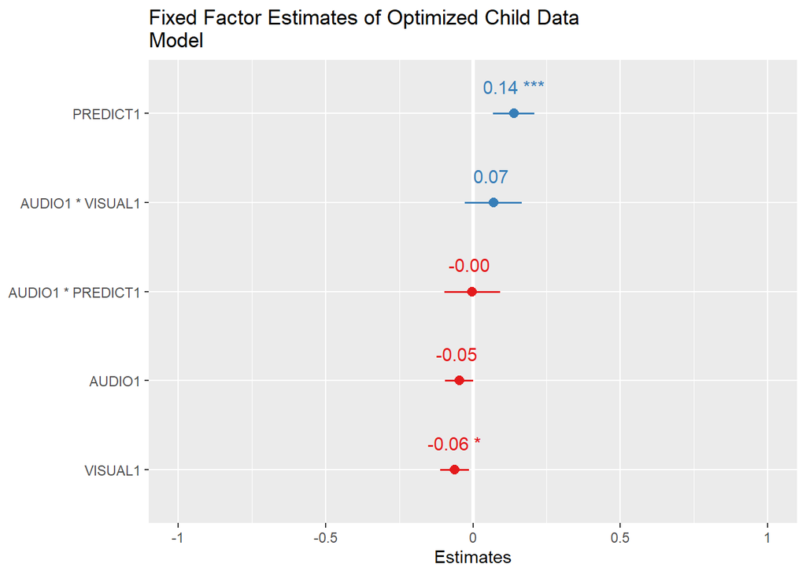